# Exploring LGBTQ+ online visibility: news volume and Google search interest

# 1 OVERVIEW

This project forms part of the Codecademy Analyse R Skill Path and is the final capstone project required to complete the course. The assessment brief asks learners to explore Google Trends using the `gtrendsR` package to assess a topic of interest, integrating at least one other dataset with their Google Trends data. The project is designed to demonstrate skills with data extraction and cleaning, statistical analysis, visualisation, and regression modelling.

In this project, I explore the relationships between UK media coverage and Google search interest for the terms ‘transgender’ and ‘LGBT’ between Nov 2020 and Nov 2025. Focusing on the UK only, weekly Google Trends relative search interest (RSI) data was combined with news volume and tone data extracted from the GDELT. Analysis of descriptive statistics, correlation tests, cross-correlation functions, and regression models were used to examine relationships.

## 1.1 Key findings

Findings show that:

- RSI for ‘transgender’ has a much more erratic trend, suggesting there may be specific drivers influencing RSI spikes (e.g. events, legislation, debates, social media).
- For both terms, RSI is correlated with with changes in media volume, and it tends to respond immediately to media volume increases.
- Independent of RSI, media volume for both keywords showed short-term lag effects with coverage in one week predicting coverage in the following week. Interestingly, the trans keyword showed medium-term lag effects, showing that media volume from a month ago is still associated with coverage four weeks later.
- Both terms have strong seasonal patterns that influence RSI, even when accounting for the impact of media volume. Tone does not appear to have a substantial impact on search behaviour.

Although this analysis cannot demonstrate any causal impacts of media volume on RSI, it does suggest that LGBT+ and trans-related Google search behaviour in the UK is often event-driven and influenced by temporal structures. Further analysis could explore potential explanations for these results and also investigate whether similar trends are observed for other identity-based Google Trends search terms.

## 1.2 Limitations

There are a number of limitations to this analysis:

- Analysis was limited to only two keywords and cannot account for trends for other related topics. I initially tried to extract Google Trends data for Google-defined topics, rather than individual keywords. A topic query would return RSI for any searches that relate to the topic rather that just search terms alone. However, Google-defined topics encoded via Google’s Knowledge Graph (/g/…) are inconsistently supported through the `gtrendsR` interface and a query for these codes did not produce any results. This analysis was thus limited to exploring the two search terms only. To increase the change of extracting usable data (i.e. no ‘NA’ or extremely low RSIs) I focued on the terms ‘transgender’, as ‘trans’ produces too much noise, and ‘LGBT’ as this aconym has been in circulation longer than more modern terms like LGBTQIA, LGBTQ+, LGBT+.
- Data extracted via gtrends() queries are not absolute counts. Instead values are normalised on a scale from 0-100 where 100 represents peak popularity for the search term in the selected time frame and region. Consequently, an RSI RSI value of 50 would show that the term was half as popular as the peak time.
- GDELT appears to have no data available for the period 15/06/2025 - 01/07/2025. To check this, I ran a separate query for only that time frame, as well as searching different, unrelated keywords. However, this checking procedure produced no data, suggesting that there was an outage of GDELT coverage over those dates. As a result, these two weeks were removed from the analysis below.
- There will naturally be overlap between these two areas, particularly given that some trans-related content maybe searched about or written about categorised under ‘LGBT+’.
- GDELT’s measurement of tone is purely dictionary based and all data extracted for this analysis showed an overall neutral trend (between -10 and +10), even though findings suggest a negative tone.
- This analysis is unable to demonstrate causality due to data limitations and the nature of social research data being unable to account for all potential factors that might influence search interest, news article volume, or sentiment.

# 2 PART 1: GOOGLE TRENDS ANALYSIS

## 2.1 Data extraction

Data was extracted via a `gtrends()` query using the `gtrendsR` package with the following parameters:

- **date range**: 5 years of data from 23 Nov 2025 (date data was extracted). The date range was thus 22 Nov 2020 to 23 Nov 2025.
- **keywords** were ‘LGBT’ and ‘Transgender’.

```r
library(pacman)
```

```r
p_load(dplyr, tidyr, ggplot2, gtrendsR, stats, readr, lubridate, rstatix, lmtest, sandwich)
```

```r
trends <- gtrends(keyword = c("LGBT", "Transgender"), geo = "GB", time = "2020-11-22 2025-11-23") # date range matches my original query which was run as time = "today+t-y"

trends_time <- trends$interest_over_time %>%
  mutate(year = year(date),
         month = month(date, label = TRUE, abbr = TRUE))
str(trends_time)
```

```
## 'data.frame':    524 obs. of  9 variables:
##  $ date    : POSIXct, format: "2020-11-22" "2020-11-29" ...
##  $ hits    : int  29 29 30 27 25 25 26 29 33 35 ...
##  $ keyword : chr  "LGBT" "LGBT" "LGBT" "LGBT" ...
##  $ geo     : chr  "GB" "GB" "GB" "GB" ...
##  $ time    : chr  "2020-11-22 2025-11-23" "2020-11-22 2025-11-23" "2020-11-22 2025-11-23" "2020-11-22 2025-11-23" ...
##  $ gprop   : chr  "web" "web" "web" "web" ...
##  $ category: int  0 0 0 0 0 0 0 0 0 0 ...
##  $ year    : num  2020 2020 2020 2020 2020 ...
##  $ month   : Ord.factor w/ 12 levels "Jan"<"Feb"<"Mar"<..: 11 11 12 12 12 12 1 1 1 1 ...
```

## 2.2 Descriptive statistics

Mean, standard deviation, and median were computed for each of the topics, broken down by month.

On average, ‘transgender’ had slightly higher mean relative search interest (RSI) and much larger standard deviations than ‘LGBT’. This suggests there was more variation in RSI week-to-week for the trans search term.

```r
mean_sd_year <- trends_time %>%
  group_by(keyword, year) %>%
  summarise(mean = mean(hits, na.rm = TRUE),
            sd = sd(hits, na.rm = TRUE),
            median = median(hits, na.rm = TRUE))
mean_sd_year
```

```
## # A tibble: 12 × 5
## # Groups:   keyword [2]
##    keyword      year  mean    sd median
##    <chr>       <dbl> <dbl> <dbl>  <dbl>
##  1 LGBT         2020  27.5  2.17   28
##  2 LGBT         2021  34.8  8.58   32
##  3 LGBT         2022  38.4  8.00   37
##  4 LGBT         2023  33.8  7.66   33
##  5 LGBT         2024  29.2  5.61   29
##  6 LGBT         2025  27.7  4.35   27
##  7 Transgender  2020  37   14.1    31.5
##  8 Transgender  2021  34.7  7.93   33
##  9 Transgender  2022  36.7  7.25   35
## 10 Transgender  2023  39.4 10.5    37
## 11 Transgender  2024  33.9 11.1    32
## 12 Transgender  2025  33.5 10.0    31
```

```r
mean_sd_ym <- trends_time %>%
    group_by(keyword, year, month) %>%
    summarise(mean = mean(hits, na.rm = TRUE),
              sd = sd(hits, na.rm = TRUE),
              median = median(hits, na.rm = TRUE)) %>%
    mutate(sd_min = mean - sd,
           sd_max = mean + sd)
mean_sd_ym
```

```
## # A tibble: 122 × 8
## # Groups:   keyword, year [12]
##    keyword  year month  mean    sd median sd_min sd_max
##    <chr>   <dbl> <ord> <dbl> <dbl>  <dbl>  <dbl>  <dbl>
##  1 LGBT     2020 Nov    29    0      29     29     29
##  2 LGBT     2020 Dec    26.8  2.36   26     24.4   29.1
##  3 LGBT     2021 Jan    35.2 10.5    33     24.7   45.7
##  4 LGBT     2021 Feb    42.8  4.79   44     38.0   47.5
##  5 LGBT     2021 Mar    33.8  4.5    32.5   29.2   38.2
##  6 LGBT     2021 Apr    29.8  1.5    29     28.2   31.2
##  7 LGBT     2021 May    39.6 13.8    34     25.8   53.4
##  8 LGBT     2021 Jun    52    5.83   51.5   46.2   57.8
##  9 LGBT     2021 Jul    33.8  3.30   33.5   30.4   37.1
## 10 LGBT     2021 Aug    33.2  2.59   33     30.6   35.8
## # ℹ 112 more rows
```

‘Transgender’ saw notable spikes in mean RSI in Nov 2020, Feb 2023, Jul 2024, and Apr 2025. It is possible that these spikes are related to the following UK-based events, but these connections are untested:

- Nov 2020 coincides with a general rise in activism related to trans identities. This could also potentially be related to Trans Day of Remembrance which falls in Nov each year.
- Feb 2023 saw the widely-reported murder of trans teenager Brianna Ghey, as well as debate on the reform of the Gender Recognition Act 2004 in Scotland and subsequent blocking of the reform bill by Westminster.
- Jul 2024 saw debates and discussion of legislation that banned the use of puberty blockers by trans individuals under the age of 18, with the UK High Court upholding the legislation following a legal challenge by several claimants at the end of that month.
- Apr 2025 spike in RSI is possibly due to the Supreme Court ruling in the For Women Scotland vs The Scottish Ministers case.

These months saw large standard deviations, suggesting that RSI peaked in 1-2 weeks of the month but sharply dropped off for other weeks in the month.

The ‘LGBT’ term saw more stable mean RSI but did have notable spikes in Jun of most years, coinciding with what is celebrated in many countries around the world as Pride Month.

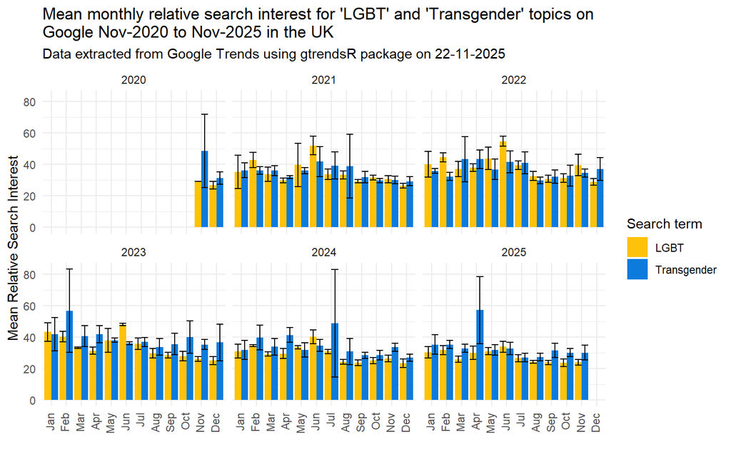

```r
monthly_means <- mean_sd_ym %>%
  ggplot(aes(x = month, y = mean, fill = keyword )) +
  geom_col(position = "dodge") +
  geom_errorbar(aes(ymin = sd_min, ymax = sd_max),
                position = position_dodge()) +
  labs(title = "Mean monthly relative search interest for 'LGBT' and 'Transgender' topics on\nGoogle Nov-2020 to Nov-2025 in the UK",
       subtitle = "Data extracted from Google Trends using gtrendsR package on 22-11-2025",
       y = "Mean Relative Search Interest",
       x = "",
       fill = "Search term") +
  scale_fill_manual(values = c("#FFC20A", "#0C7BDC")) +
  theme_minimal() +
  theme(axis.text.x = element_text(angle = 90, hjust = 1, vjust = 0.3)) +
  facet_wrap(~year)
monthly_means
```

## 2.3 Statistical analysis

T-tests were run to determine if there was a significant difference between mean relative search interest (RSI) for each search term. Overall the slightly higher mean RSI observed in the ‘transgender’ search term was found to be statistically significant.

Levene’s test was first run to test for equal variance. No significant difference in variance was observed between the terms, satisfying the assumption of equal variances of a two-sample t-test.

```r
levene <- levene_test(hits ~ keyword, data = trends_time)
levene
```

```
## # A tibble: 1 × 4
##     df1   df2 statistic     p
##   <int> <int>     <dbl> <dbl>
## 1     1   522   0.00581 0.939
```

```r
t_test <- t.test(hits ~ keyword, data = trends_time, var.equal = TRUE)
t_test
```

```
##
##  Two Sample t-test
##
## data:  hits by keyword
## t = -3.8266, df = 522, p-value = 0.0001457
## alternative hypothesis: true difference in means between group LGBT and group Transgender is not equal to 0
## 95 percent confidence interval:
##  -4.493961 -1.444971
## sample estimates:
##        mean in group LGBT mean in group Transgender
##                  32.75191                  35.72137
```

## 2.4 Time series analysis

To understand temporal patterns, I plotted RSI over time, as well as conducting linear regression to understand seasonal trends.

### 2.4.1 Plotting RSI over time

Overall, ‘LGBT’ saw a gradual downwards trend from Nov 2020 to Nov 2025. Conversely, the trans term showed a much more erratic trend with more spikes.

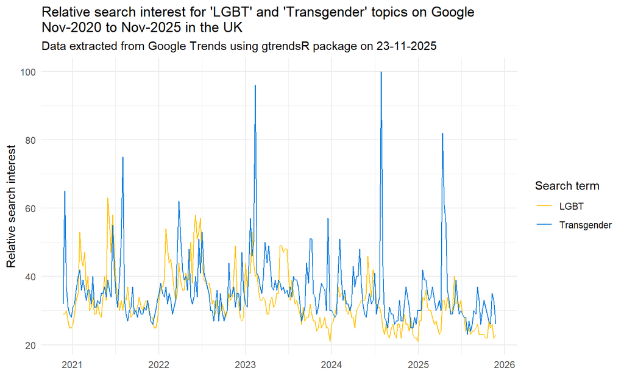

```r
time_chart <- trends_time %>%
  ggplot(aes(x = date, y= hits, colour = keyword)) +
  geom_line() +
  labs(title = "Relative search interest for 'LGBT' and 'Transgender' topics on Google\nNov-2020 to Nov-2025 in the UK",
       subtitle = "Data extracted from Google Trends using gtrendsR package on 23-11-2025",
       x = "",
       y = "Relative search interest",
       colour = "Search term") +
  scale_x_date(breaks = "1 year",
               date_labels = ("%Y")) +
  theme_minimal()+
  scale_colour_manual(values = c("#FFC20A", "#0C7BDC"))
time_chart
```

### 2.4.2 Linear regression modelling

Linear regression was run to determine temporal and seasonal effects. Month was encoded using orthogonal polynomial contrasts and models were fit for each keyword. Two models were fitted for each search term:

- Model 1: RSI as a function of year to understand the effect of change between years in predicting changes in RSI
- Model 2: RSI as a function of year and month to model seasonal variation and understand how in-year changes can predict RSI changes.

RSI is bounded between 0 and 100, which may violate linearity assumptions. Therefore, results of this regression should be interpreted descriptively rather than as precise effect sizes.

**‘Transgender’ search term**

Model 1 showed that there were no statistically significant annual effects on RSI.

Model 2 found evidence of a seasonal pattern in RSI. The largest effect was a clear, significant linear pattern denoting that some months were consistently higher in RSI and others lower in a roughly straight-line trend. Some of the higher order polynomials were also significant suggesting smaller ups and downs in specific months. However the R2 for this model was relatively low, suggesting that there are other factors unaccounted for that are influencing RSI.

**‘LGBT’ search term**

Model 1 found a statistically significant year-on-year decline in RSI. However, the R2 for the model was relatively low, suggesting that there are other factors influencing RSI.

Model 2 found very strong evidence of seasonal variation, with a large increase in R2, suggesting that adding month as a predictor greatly increased the predictive ability of this model for this search term. The linear component was highly significant indicating a consistent linear difference between early-year RSI and later-year RSI. The quadratic component was also highly significant, suggesting that the seasonal pattern has a broad curved shape rather than being purely linear. Several higher-order polynomials were also significant, indicating additional bends and curves across the year. Overall, this suggests that ‘LGBT’ RSI follows a strongly seasonal pattern with multiple rises and dips throughout the year, rather than a single peak or trough.

```r
lm_trans <- lm(hits ~ year, data = subset(trends_time, keyword == "Transgender"))
summary(lm_trans)
```

```
##
## Call:
## lm(formula = hits ~ year, data = subset(trends_time, keyword ==
##     "Transgender"))
##
## Residuals:
##     Min      1Q  Median      3Q     Max
## -11.682  -5.679  -1.682   2.331  64.825
##
## Coefficients:
##              Estimate Std. Error t value Pr(>|t|)
## (Intercept) 1033.5759   837.5130   1.234    0.218
## year          -0.4933     0.4140  -1.191    0.235
##
## Residual standard error: 9.718 on 260 degrees of freedom
## Multiple R-squared:  0.00543,    Adjusted R-squared:  0.001605
## F-statistic:  1.42 on 1 and 260 DF,  p-value: 0.2346
```

```r
lm_trans_month <- lm(hits ~ year + month, data = subset(trends_time, keyword == "Transgender"))
summary(lm_trans_month)
```

```
##
## Call:
## lm(formula = hits ~ year + month, data = subset(trends_time,
##     keyword == "Transgender"))
##
## Residuals:
##     Min      1Q  Median      3Q     Max
## -14.211  -4.674  -2.233   2.210  62.114
##
## Coefficients:
##               Estimate Std. Error t value Pr(>|t|)
## (Intercept) 1400.10174  813.24545   1.722   0.0864 .
## year          -0.67444    0.40202  -1.678   0.0947 .
## month.L       -8.48653    1.99580  -4.252    3e-05 ***
## month.Q       -1.92733    1.98978  -0.969   0.3337
## month.C        3.95658    1.98246   1.996   0.0470 *
## month^4       -1.05313    1.98294  -0.531   0.5958
## month^5       -1.03933    2.00133  -0.519   0.6040
## month^6       -2.36367    2.01225  -1.175   0.2413
## month^7       -1.05780    1.98821  -0.532   0.5952
## month^8       -0.13209    1.98295  -0.067   0.9469
## month^9        4.43151    1.99830   2.218   0.0275 *
## month^10      -4.98702    1.99517  -2.500   0.0131 *
## month^11       0.06786    1.98452   0.034   0.9728
## ---
## Signif. codes:  0 '***' 0.001 '**' 0.01 '*' 0.05 '.' 0.1 ' ' 1
##
## Residual standard error: 9.289 on 249 degrees of freedom
## Multiple R-squared:  0.1299, Adjusted R-squared:  0.08794
## F-statistic: 3.097 on 12 and 249 DF,  p-value: 0.0004158
```

```r
lm_lgbt <- lm(hits ~ year, data = subset(trends_time, keyword == "LGBT"))
summary(lm_lgbt)
```

```
##
## Call:
## lm(formula = hits ~ year, data = subset(trends_time, keyword ==
##     "LGBT"))
##
## Residuals:
##     Min      1Q  Median      3Q     Max
## -13.364  -5.545  -1.545   3.515  26.575
##
## Coefficients:
##              Estimate Std. Error t value Pr(>|t|)
## (Intercept) 3957.1343   641.6776   6.167 2.65e-09 ***
## year          -1.9400     0.3172  -6.116 3.51e-09 ***
## ---
## Signif. codes:  0 '***' 0.001 '**' 0.01 '*' 0.05 '.' 0.1 ' ' 1
##
## Residual standard error: 7.446 on 260 degrees of freedom
## Multiple R-squared:  0.1258, Adjusted R-squared:  0.1224
## F-statistic:  37.4 on 1 and 260 DF,  p-value: 3.508e-09
```

```r
lm_lgbt_month <- lm(hits ~ year + month, data = subset(trends_time, keyword == "LGBT"))
summary(lm_lgbt_month)
```

```
##
## Call:
## lm(formula = hits ~ year + month, data = subset(trends_time,
##     keyword == "LGBT"))
##
## Residuals:
##      Min       1Q   Median       3Q      Max
## -14.7210  -2.6667  -0.2213   2.1238  21.1386
##
## Coefficients:
##              Estimate Std. Error t value Pr(>|t|)
## (Intercept) 4717.5865   425.2032  11.095  < 2e-16 ***
## year          -2.3159     0.2102 -11.018  < 2e-16 ***
## month.L      -13.1097     1.0435 -12.563  < 2e-16 ***
## month.Q       -5.7777     1.0404  -5.554 7.17e-08 ***
## month.C        0.8935     1.0365   0.862 0.389506
## month^4        4.7797     1.0368   4.610 6.44e-06 ***
## month^5       -3.8318     1.0464  -3.662 0.000306 ***
## month^6       -9.1987     1.0521  -8.743 3.44e-16 ***
## month^7        5.9590     1.0395   5.732 2.85e-08 ***
## month^8        1.7589     1.0368   1.697 0.091036 .
## month^9       -3.3871     1.0448  -3.242 0.001350 **
## month^10      -1.3070     1.0432  -1.253 0.211396
## month^11       3.8929     1.0376   3.752 0.000218 ***
## ---
## Signif. codes:  0 '***' 0.001 '**' 0.01 '*' 0.05 '.' 0.1 ' ' 1
##
## Residual standard error: 4.857 on 249 degrees of freedom
## Multiple R-squared:  0.6438, Adjusted R-squared:  0.6267
## F-statistic: 37.51 on 12 and 249 DF,  p-value: < 2.2e-16
```

# 3 PART 2: GDELT DATA ANALYSIS

## 3.1 Data extraction

Note: GDELT’s tone measure is dictionary-based, using Lexicoder for political discourse, and values are scaled by word count. Scores are then averaged across all articles in a day. GDELT tone ranges from -100 (all words are negative) to +100 (all words are positive) but most news will be neutral, falling between -10 and +10. Because GDELT’s tone measurement is purely based on dictionary meanings, it cannot take into account nuanced measures of sentiment or language features like sarcasm.

GDELT queries provide data for each day in the specified date range. To be comparable to Google Trends data, I aggregated GDELT data by week which increases the possibility that day-to-day fluctuations may be masked through this aggregation.

```r
#------------ url elements -----------------------------------
base_url <- "https://api.gdeltproject.org/api/v2/doc/doc"

query_trans <- "transgender"
query_lgbt  <- "LGBT"

start <- "20201122000000"  # 22 Nov 2020
end   <- "20251123000000"  # 23 Nov 2025, final day of Gtrends query

#------------ building urls ----------------------------------
url_trans_vol <- paste0(
  base_url,
  "?query=", URLencode(query_trans, reserved = TRUE),
  "&mode=TimelineVolRaw",
  "&startdatetime=", start,
  "&enddatetime=", end,
  "&sourcecountry=GB",
  "&format=csv"
)

url_lgbt_vol <- paste0(
  base_url,
  "?query=", URLencode(query_lgbt, reserved = TRUE),
  "&mode=TimelineVolRaw",
  "&startdatetime=", start,
  "&enddatetime=", end,
  "&sourcecountry=GB",
  "&format=csv"
)

#------------ extracting data -------------------------------
gdelt_trans_vol <- read.csv(url_trans_vol)
gdelt_lgbt_vol  <- read.csv(url_lgbt_vol)

#---------- cleaning - trans --------------------------------
gdelt_trans_vol <- gdelt_trans_vol %>%
  pivot_wider(names_from = Series,
              values_from = Value)
colnames(gdelt_trans_vol) [2] <- "count_articles"
colnames(gdelt_trans_vol) [3] <- "total_articles"
gdelt_trans_vol$Date <- as.Date(trimws(as.character(gdelt_trans_vol$Date)), format = "%Y-%m-%d")
str(gdelt_trans_vol)
```

```
## tibble [1,810 × 3] (S3: tbl_df/tbl/data.frame)
##  $ Date          : Date[1:1810], format: "2020-11-22" "2020-11-23" ...
##  $ count_articles: int [1:1810] 223 326 564 517 393 317 293 256 387 1664 ...
##  $ total_articles: int [1:1810] 246932 411141 448919 447213 406221 385161 260516 245823 404039 445234 ...
```

```r
gdelt_trans_vol_week <- gdelt_trans_vol %>%
  mutate(week = floor_date(Date, unit = "week", week_start = 7)) %>%
  group_by(week) %>%
  summarise(
    weekly_count = sum(count_articles, na.rm = TRUE),
    weekly_total = sum(total_articles, na.rm = TRUE),
    weekly_proportion = weekly_count / weekly_total * 100) %>%
  mutate(year = year(week),
         month = month(week, label = TRUE, abbr = TRUE),
         keyword = "Transgender")
str(gdelt_trans_vol_week)
```

```
## tibble [260 × 7] (S3: tbl_df/tbl/data.frame)
##  $ week             : Date[1:260], format: "2020-11-22" "2020-11-29" ...
##  $ weekly_count     : int [1:260] 2633 5291 2789 2396 2076 1457 1383 1759 5404 8974 ...
##  $ weekly_total     : int [1:260] 2606103 2689944 2695830 2604345 2194470 2068081 2423888 2587959 2560058 2613348 ...
##  $ weekly_proportion: num [1:260] 0.101 0.1967 0.1035 0.092 0.0946 ...
##  $ year             : num [1:260] 2020 2020 2020 2020 2020 ...
##  $ month            : Ord.factor w/ 12 levels "Jan"<"Feb"<"Mar"<..: 11 11 12 12 12 12 1 1 1 1 ...
##  $ keyword          : chr [1:260] "Transgender" "Transgender" "Transgender" "Transgender" ...
```

```r
#------------- cleaning - LGBT -------------------------
gdelt_lgbt_vol <- gdelt_lgbt_vol %>%
  pivot_wider(names_from = Series,
              values_from = Value)
colnames(gdelt_lgbt_vol) [2] <- "count_articles"
colnames(gdelt_lgbt_vol) [3] <- "total_articles"

gdelt_lgbt_vol$Date <- as.Date(trimws(as.character(gdelt_lgbt_vol$Date)), format = "%Y-%m-%d")
str(gdelt_lgbt_vol)
```

```
## tibble [1,810 × 3] (S3: tbl_df/tbl/data.frame)
##  $ Date          : Date[1:1810], format: "2020-11-22" "2020-11-23" ...
##  $ count_articles: int [1:1810] 179 209 213 174 264 275 172 127 183 438 ...
##  $ total_articles: int [1:1810] 246932 411141 448919 447213 406221 385161 260516 245823 404039 445234 ...
```

```r
gdelt_lgbt_vol_week <- gdelt_lgbt_vol %>%
  mutate(week = floor_date(Date, unit = "week", week_start = 7)) %>%
  group_by(week) %>%
  summarise(
    weekly_count = sum(count_articles, na.rm = TRUE),
    weekly_total = sum(total_articles, na.rm = TRUE),
    weekly_proportion = weekly_count / weekly_total * 100) %>%
  mutate(year = year(week),
         month = month(week, label = TRUE, abbr = TRUE),
         keyword = "LGBT")
str(gdelt_lgbt_vol_week)
```

```
## tibble [260 × 7] (S3: tbl_df/tbl/data.frame)
##  $ week             : Date[1:260], format: "2020-11-22" "2020-11-29" ...
##  $ weekly_count     : int [1:260] 1486 2055 1850 1822 899 1044 976 1134 1757 2232 ...
##  $ weekly_total     : int [1:260] 2606103 2689944 2695830 2604345 2194470 2068081 2423888 2587959 2560058 2613348 ...
##  $ weekly_proportion: num [1:260] 0.057 0.0764 0.0686 0.07 0.041 ...
##  $ year             : num [1:260] 2020 2020 2020 2020 2020 ...
##  $ month            : Ord.factor w/ 12 levels "Jan"<"Feb"<"Mar"<..: 11 11 12 12 12 12 1 1 1 1 ...
##  $ keyword          : chr [1:260] "LGBT" "LGBT" "LGBT" "LGBT" ...
```

```r
#--------------- combining -----------------------------
gdelt_vol_comb <- gdelt_trans_vol_week %>%
  rbind(gdelt_lgbt_vol_week)
head(gdelt_vol_comb, 10)
```

```
## # A tibble: 10 × 7
##    week       weekly_count weekly_total weekly_proportion  year month keyword
##    <date>            <int>        <int>             <dbl> <dbl> <ord> <chr>
##  1 2020-11-22         2633      2606103            0.101   2020 Nov   Transgend…
##  2 2020-11-29         5291      2689944            0.197   2020 Nov   Transgend…
##  3 2020-12-06         2789      2695830            0.103   2020 Dec   Transgend…
##  4 2020-12-13         2396      2604345            0.0920  2020 Dec   Transgend…
##  5 2020-12-20         2076      2194470            0.0946  2020 Dec   Transgend…
##  6 2020-12-27         1457      2068081            0.0705  2020 Dec   Transgend…
##  7 2021-01-03         1383      2423888            0.0571  2021 Jan   Transgend…
##  8 2021-01-10         1759      2587959            0.0680  2021 Jan   Transgend…
##  9 2021-01-17         5404      2560058            0.211   2021 Jan   Transgend…
## 10 2021-01-24         8974      2613348            0.343   2021 Jan   Transgend…
```

```r
# Note: base URL elements are the same as used in the chunk above to extract volume data.
#---------- building urls --------------------------------
url_trans_tone <- paste0(
  base_url,
  "?query=", URLencode(query_trans, reserved = TRUE),
  "&mode=TimelineTone",
  "&startdatetime=", start,
  "&enddatetime=", end,
  "&sourcecountry=GB",
  "&format=csv"
)
url_lgbt_tone <- paste0(
  base_url,
  "?query=", URLencode(query_lgbt, reserved = TRUE),
  "&mode=TimelineTone",
  "&startdatetime=", start,
  "&enddatetime=", end,
  "&sourcecountry=GB",
  "&format=csv"
)

#---------- extracting data -----------------------------
gdelt_trans_tone <- read.csv(url_trans_tone)
gdelt_lgbt_tone <- read.csv(url_lgbt_tone)

#---------- cleaning - trans ---------------------------
str(gdelt_trans_tone)
```

```
## 'data.frame':    1810 obs. of  3 variables:
##  $ Date  : chr  "2020-11-22" "2020-11-23" "2020-11-24" "2020-11-25" ...
##  $ Series: chr  "Average Tone" "Average Tone" "Average Tone" "Average Tone" ...
##  $ Value : num  -1.53 -1.287 -0.946 -1.723 -1.665 ...
```

```r
colnames(gdelt_trans_tone)[2] <- "sentiment"
colnames(gdelt_trans_tone)[3] <- "sentiment_value"
gdelt_trans_tone$Date <- as.Date(gdelt_trans_tone$Date)

gdelt_trans_tone <- gdelt_trans_tone %>%
  mutate(week = floor_date(Date, unit = "week", week_start = 7)) %>%
  mutate(year = year(Date),
         month = month(Date, label = TRUE, abbr = TRUE))

gdelt_trans_tone_week <- gdelt_trans_tone %>%
  group_by(week) %>%
  summarise(
    week_avg_sentiment = mean(sentiment_value)) %>%
  mutate(week = floor_date(week, unit = "week", week_start = 7)) %>%
  mutate(year = year(week),
         month = month(week, label = TRUE, abbr = TRUE),
         keyword = "Transgender")
str(gdelt_trans_tone_week)
```

```
## tibble [260 × 5] (S3: tbl_df/tbl/data.frame)
##  $ week              : Date[1:260], format: "2020-11-22" "2020-11-29" ...
##  $ week_avg_sentiment: num [1:260] -1.214 0.117 -0.404 -0.842 0.853 ...
##  $ year              : num [1:260] 2020 2020 2020 2020 2020 ...
##  $ month             : Ord.factor w/ 12 levels "Jan"<"Feb"<"Mar"<..: 11 11 12 12 12 12 1 1 1 1 ...
##  $ keyword           : chr [1:260] "Transgender" "Transgender" "Transgender" "Transgender" ...
```

```r
#--------- cleaning - LGBT -------------------------------
str(gdelt_lgbt_tone)
```

```
## 'data.frame':    1810 obs. of  3 variables:
##  $ Date  : chr  "2020-11-22" "2020-11-23" "2020-11-24" "2020-11-25" ...
##  $ Series: chr  "Average Tone" "Average Tone" "Average Tone" "Average Tone" ...
##  $ Value : num  -2.236 -1.802 -0.734 -0.34 -2.101 ...
```

```r
colnames(gdelt_lgbt_tone)[2] <- "sentiment"
colnames(gdelt_lgbt_tone)[3] <- "sentiment_value"
gdelt_lgbt_tone$Date <- as.Date(gdelt_lgbt_tone$Date)

gdelt_lgbt_tone <- gdelt_lgbt_tone %>%
  mutate(week = floor_date(Date, unit = "week", week_start = 7)) %>%
  mutate(year = year(Date),
         month = month(Date, label = TRUE, abbr = TRUE))

gdelt_lgbt_tone_week <- gdelt_lgbt_tone %>%
  group_by(week) %>%
  summarise(
    week_avg_sentiment = mean(sentiment_value)) %>%
  mutate(week = floor_date(week, unit = "week", week_start = 7)) %>%
  mutate(year = year(week),
         month = month(week, label = TRUE, abbr = TRUE),
         keyword = "LGBT")
str(gdelt_lgbt_tone_week)
```

```
## tibble [260 × 5] (S3: tbl_df/tbl/data.frame)
##  $ week              : Date[1:260], format: "2020-11-22" "2020-11-29" ...
##  $ week_avg_sentiment: num [1:260] -1.448 -1.229 -0.307 -0.677 -0.406 ...
##  $ year              : num [1:260] 2020 2020 2020 2020 2020 ...
##  $ month             : Ord.factor w/ 12 levels "Jan"<"Feb"<"Mar"<..: 11 11 12 12 12 12 1 1 1 1 ...
##  $ keyword           : chr [1:260] "LGBT" "LGBT" "LGBT" "LGBT" ...
```

```r
#---------- combining ----------------------------------
gdelt_tone_comb <- gdelt_trans_tone_week %>%
  rbind(gdelt_lgbt_tone_week)
head(gdelt_tone_comb, 10)
```

```
## # A tibble: 10 × 5
##    week       week_avg_sentiment  year month keyword
##    <date>                  <dbl> <dbl> <ord> <chr>
##  1 2020-11-22             -1.21   2020 Nov   Transgender
##  2 2020-11-29              0.117  2020 Nov   Transgender
##  3 2020-12-06             -0.404  2020 Dec   Transgender
##  4 2020-12-13             -0.842  2020 Dec   Transgender
##  5 2020-12-20              0.853  2020 Dec   Transgender
##  6 2020-12-27             -0.999  2020 Dec   Transgender
##  7 2021-01-03             -0.687  2021 Jan   Transgender
##  8 2021-01-10             -1.27   2021 Jan   Transgender
##  9 2021-01-17             -0.601  2021 Jan   Transgender
## 10 2021-01-24             -0.570  2021 Jan   Transgender
```

## 3.2 Descriptive statistics

Descriptive statistics (mean, standard deviation, min, max) were computed for both search terms and for both volume and tone.

Overall, the ‘transgender’ search term had a higher mean volume of articles compared to ‘LGBT’, with relatively large standard deviations. ‘LGBT’ also saw a graduate decrease in mean volume over time.

```r
vol_mean_sd <- gdelt_vol_comb %>%
  group_by(keyword, year, month) %>%
  summarise(
    mean_prop = mean(weekly_proportion),
    sd_prop = sd(weekly_proportion),
    mean_count = mean(weekly_count),
    sd_count = sd(weekly_count),
    mean_total = mean(weekly_total),
    sd_total = sd(weekly_total)) %>%
  mutate(sd_max_prop = mean_prop + sd_prop,
         sd_min_prop = mean_prop - sd_prop,
         sd_max_count = mean_count + sd_count,
         sd_min_count = mean_count - sd_count)
```

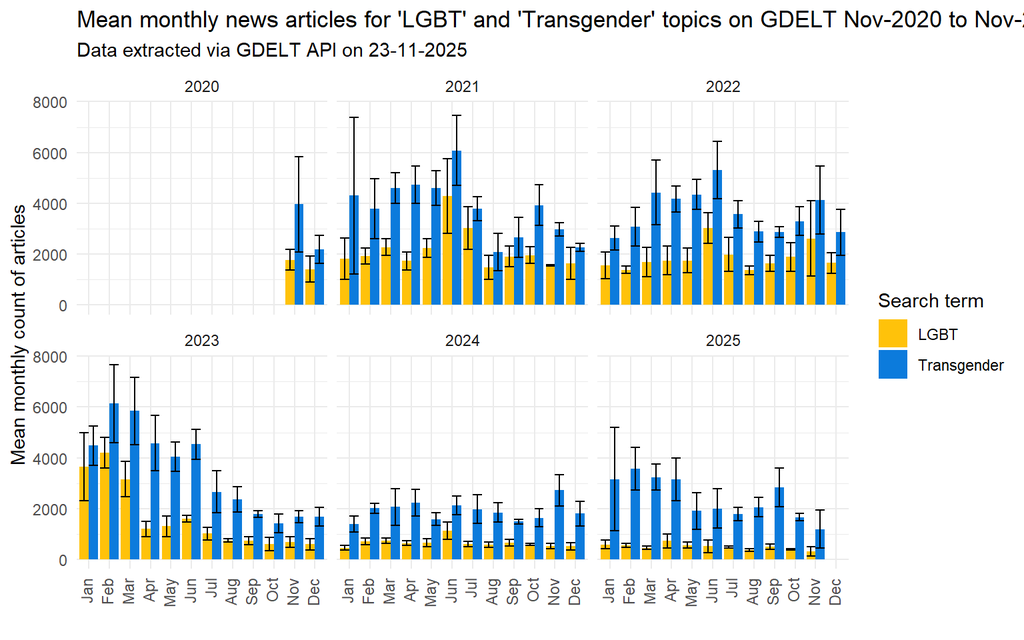

```r
monthly_vol_means <- vol_mean_sd %>%
  ggplot(aes(x = month, y = mean_count, fill = keyword )) +
  geom_col(position = "dodge") +
  geom_errorbar(aes(ymin = sd_min_count, ymax = sd_max_count),
                position = position_dodge()) +
  facet_wrap(~year) +
  labs(title = "Mean monthly news articles for 'LGBT' and 'Transgender' topics on GDELT Nov-2020 to Nov-2025 in the UK",
       subtitle = "Data extracted via GDELT API on 23-11-2025",
       y = "Mean monthly count of articles",
       x = "",
       fill = "Search term") +
  scale_fill_manual(values = c("#FFC20A", "#0C7BDC")) +
  theme_minimal() +
  theme(axis.text.x = element_text(angle = 90, hjust = 1, vjust = 0.3))
monthly_vol_means
```

Tone for the trans term showed overall lower sentiment than for ‘LGBT’, with no means or standard deviations rising above 0 from 2021 onwards. However, both search terms had no articles with an monthly mean tone above 0 but some months had large standard deviations, indicating that some weeks were much more positive than others.

GDELT tone is purely dictionary based and cannot account for linguistic features like sarcasm or social aspects like social media comments. Although all sentiment is negative, it is still within GDELT’s boundaries for neutral language.

```r
tone_mean_sd <- gdelt_tone_comb %>%
  group_by(keyword, year, month) %>%
  summarise(
    mean_sentiment = mean(week_avg_sentiment),
    sd_sentiment = sd(week_avg_sentiment)) %>%
  mutate(sd_max = mean_sentiment + sd_sentiment,
         sd_min = mean_sentiment - sd_sentiment,
         direction = ifelse(mean_sentiment >= 0, "Positive", "Negative"))
```

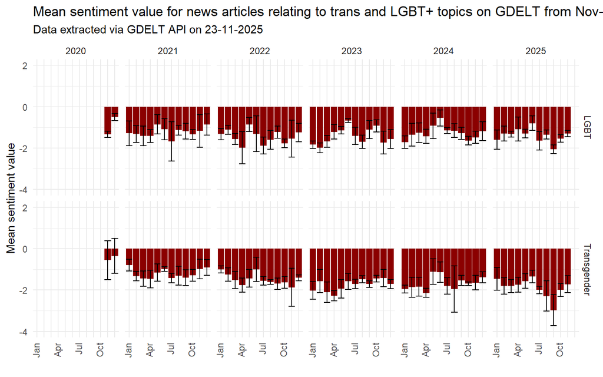

```r
monthly_tone_means <- tone_mean_sd %>%
  ggplot(aes(x = month, y = mean_sentiment, fill = direction)) +
  geom_col() +
  geom_errorbar(aes(ymin = sd_min, ymax = sd_max),
                position = position_dodge()) +
  facet_grid(keyword ~ year) +
  labs(title = "Mean sentiment value for news articles relating to trans and LGBT+ topics on GDELT from Nov-2020 to Nov-2025",
       subtitle = "Data extracted via GDELT API on 23-11-2025",
       y = "Mean sentiment value",
       x = "") +
  scale_x_discrete(labels = c(Jan = "Jan",
                              Feb = "",
                              Mar = "",
                              Apr = "Apr",
                              May = "",
                              Jun = "",
                              Jul = "Jul",
                              Aug = "",
                              Sep = "",
                              Oct = "Oct",
                              Nov = "",
                              Dec = "")) +
  scale_fill_manual(values = c("Positive" = "green3", "Negative" = "red4")) +
  scale_y_continuous(limits = c(2, -4)) +
  theme_minimal()+
  theme(axis.text.x = element_text(angle = 90, hjust = 1, vjust = 0.3),
        legend.position = "none")
monthly_tone_means
```

# 4 PART 3: COMBINING GOOGLE TRENDS AND GDELT DATA

Google Trends data and GDELT data extracted and analysed above were combined to conduct a more nuanced analysis, addressing the following evaluation questions:

1. How do RSI and volume change over time and is there any visual connection between them? What about RSI and tone?
2. Do media volume spikes correlate with search interest spikes?
3. Do changes in tone correlate with search interest changes?
4. Do media volume and/or tone have any predictive effect on measuring RSI?
5. Can we detect lag between media volume and RSI?

To analyse these questions, I created a combined data frame that brought together Google Trends and GDELT data. When examining the data, I noticed that GDELT had missing data from 15-06-2025 to 01-07-2025, as outlined in the ‘Limitations’ section above. These weeks were filtered out of the combined data frame.

```r
trans_full_df <- trends_time %>%
  filter(keyword == "Transgender") %>%
  mutate(week = as.Date(date)) %>%
  select(week, hits) %>%
  left_join(gdelt_trans_vol_week, by = "week") %>%
  select(-year, -month, -keyword) %>%
  left_join(gdelt_trans_tone_week)
str(trans_full_df)
```

```
## 'data.frame':    262 obs. of  9 variables:
##  $ week              : Date, format: "2020-11-22" "2020-11-29" ...
##  $ hits              : int  32 65 37 31 29 28 31 32 36 40 ...
##  $ weekly_count      : int  2633 5291 2789 2396 2076 1457 1383 1759 5404 8974 ...
##  $ weekly_total      : int  2606103 2689944 2695830 2604345 2194470 2068081 2423888 2587959 2560058 2613348 ...
##  $ weekly_proportion : num  0.101 0.1967 0.1035 0.092 0.0946 ...
##  $ week_avg_sentiment: num  -1.214 0.117 -0.404 -0.842 0.853 ...
##  $ year              : num  2020 2020 2020 2020 2020 ...
##  $ month             : Ord.factor w/ 12 levels "Jan"<"Feb"<"Mar"<..: 11 11 12 12 12 12 1 1 1 1 ...
##  $ keyword           : chr  "Transgender" "Transgender" "Transgender" "Transgender" ...
```

```r
lgbt_full_df <- trends_time %>%
  filter(keyword == "LGBT") %>%
  mutate(week = as.Date(date)) %>%
  select(week, hits) %>%
  left_join(gdelt_lgbt_vol_week, by = "week") %>%
  select(-year, -month, -keyword) %>%
  left_join(gdelt_lgbt_tone_week)
str(lgbt_full_df)
```

```
## 'data.frame':    262 obs. of  9 variables:
##  $ week              : Date, format: "2020-11-22" "2020-11-29" ...
##  $ hits              : int  29 29 30 27 25 25 26 29 33 35 ...
##  $ weekly_count      : int  1486 2055 1850 1822 899 1044 976 1134 1757 2232 ...
##  $ weekly_total      : int  2606103 2689944 2695830 2604345 2194470 2068081 2423888 2587959 2560058 2613348 ...
##  $ weekly_proportion : num  0.057 0.0764 0.0686 0.07 0.041 ...
##  $ week_avg_sentiment: num  -1.448 -1.229 -0.307 -0.677 -0.406 ...
##  $ year              : num  2020 2020 2020 2020 2020 ...
##  $ month             : Ord.factor w/ 12 levels "Jan"<"Feb"<"Mar"<..: 11 11 12 12 12 12 1 1 1 1 ...
##  $ keyword           : chr  "LGBT" "LGBT" "LGBT" "LGBT" ...
```

```r
full_data <- trans_full_df %>%
  rbind(lgbt_full_df)

full_data_clean <- full_data %>%
  filter(!is.na(weekly_count)) %>%
  arrange(keyword, week)
head(full_data_clean, 10)
```

```
##          week hits weekly_count weekly_total weekly_proportion
## 1  2020-11-22   29         1486      2606103        0.05702000
## 2  2020-11-29   29         2055      2689944        0.07639564
## 3  2020-12-06   30         1850      2695830        0.06862451
## 4  2020-12-13   27         1822      2604345        0.06996001
## 5  2020-12-20   25          899      2194470        0.04096661
## 6  2020-12-27   25         1044      2068081        0.05048158
## 7  2021-01-03   26          976      2423888        0.04026589
## 8  2021-01-10   29         1134      2587959        0.04381831
## 9  2021-01-17   33         1757      2560058        0.06863126
## 10 2021-01-24   35         2232      2613348        0.08540768
##    week_avg_sentiment year month keyword
## 1          -1.4483857 2020   Nov    LGBT
## 2          -1.2285714 2020   Nov    LGBT
## 3          -0.3069571 2020   Dec    LGBT
## 4          -0.6773714 2020   Dec    LGBT
## 5          -0.4058143 2020   Dec    LGBT
## 6          -0.5874714 2020   Dec    LGBT
## 7          -1.2113000 2021   Jan    LGBT
## 8          -1.0811857 2021   Jan    LGBT
## 9          -0.5633571 2021   Jan    LGBT
## 10         -1.4041571 2021   Jan    LGBT
```

## 4.1 Visual trends: RSI and volume, RSI and tone

Relative search interest (RSI) on Google was plotted against media volume, and against media tone, to see if any visual relationships or trends could be observed between them. This required scaling volume/tone to match the RSI axis.

Volume saw the following trends:

- For ‘LGBT’, RSI remained relatively steady whereas media volume dropped off around mid-2023.
- ‘Transgender’ showed a more erratic pattern for both RSI and media volume with more spikes and dips over time.

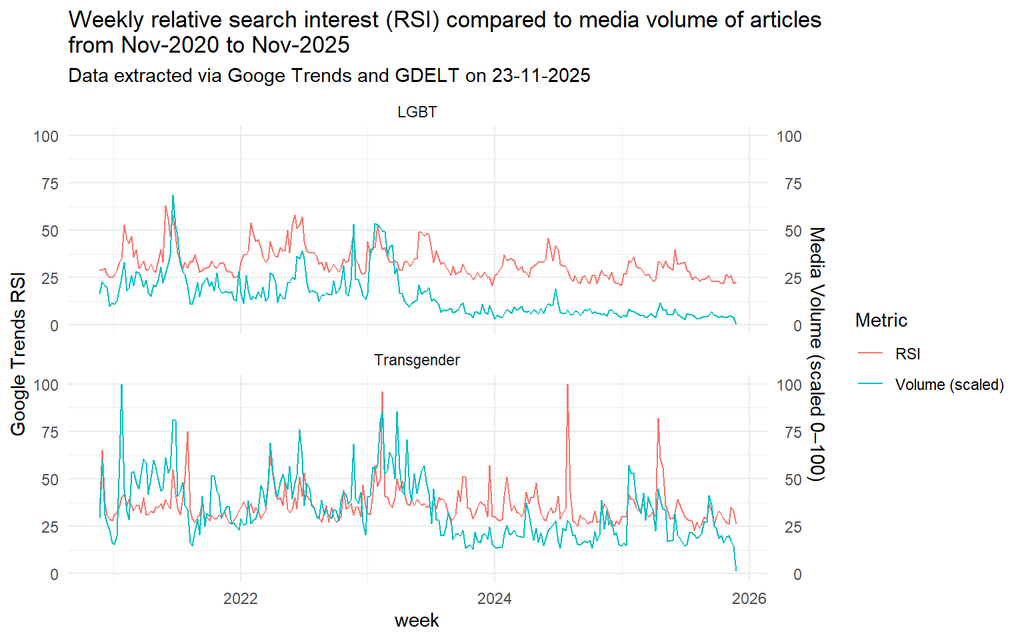

```r
time_volume <- full_data_clean %>%
  ggplot(aes(x = week)) +
  geom_line(aes(y = hits, colour = "RSI")) +
  geom_line(aes(y = weekly_count / max(weekly_count) * 100,
                colour = "Volume (scaled)")) +
  scale_y_continuous(
    name = "Google Trends RSI",
    sec.axis = sec_axis(~ .,
                        name = "Media Volume (scaled 0–100)")
  ) +
  labs(title = "Weekly relative search interest (RSI) compared to media volume of articles\nfrom Nov-2020 to Nov-2025",
       subtitle = "Data extracted via Googe Trends and GDELT on 23-11-2025",
       colour = "Metric") +
  theme_minimal() +
  facet_wrap(~keyword,  nrow = 2, ncol = 1)
time_volume
```

Conversely, mapping RSI against tone revealed no particularly clear trends observable between RSI and tone. For both terms, tone remained relatively steady over time, with a handful of notable dips. Interestingly, the ‘trans’ term saw a very small overall decline in tone from late 2020 to early 2022.

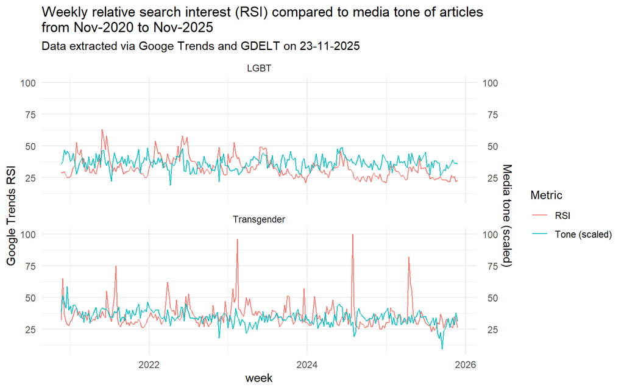

```r
time_series_tone <- full_data_clean %>%
  ggplot(aes(x = week)) +
  geom_line(aes(y = hits, colour = "RSI")) +
  geom_line(aes(y = (week_avg_sentiment + 5) * 10,
                colour = "Tone (scaled)")) +
  scale_y_continuous(
    name = "Google Trends RSI",
    sec.axis = sec_axis(~ .,
                        name = "Media tone (scaled)")
  ) +
  labs(title = "Weekly relative search interest (RSI) compared to media tone of articles\nfrom Nov-2020 to Nov-2025",
       subtitle = "Data extracted via Googe Trends and GDELT on 23-11-2025",
       colour = "Metric") +
  theme_minimal() +
  facet_wrap(~keyword, nrow = 2, ncol = 1)
time_series_tone
```

## 4.2 Correlation between media volume and RSI

The correlation between media volume (weekly count of articles) and RSI (hits) was computed using both Spearman’s Rho and Kendall’s Tau B, following a significant Shapiro Wilks test. Spearman’s Rho was initially used but due to ties, Kendall’s Tau B was preferred.

Plotting both search terms visually showed that the ‘transgender’ search term had many more outliers and overall showed a less linear relationship compared to ‘LGBT’.

```r
shapiro.test(trans_full_df$weekly_count) # p<0.001
```

```
##
##  Shapiro-Wilk normality test
##
## data:  trans_full_df$weekly_count
## W = 0.92723, p-value = 5.478e-10
```

```r
shapiro.test(trans_full_df$hits) # p<0.001
```

```
##
##  Shapiro-Wilk normality test
##
## data:  trans_full_df$hits
## W = 0.73065, p-value < 2.2e-16
```

```r
shapiro.test(lgbt_full_df$hits) #p<0.001
```

```
##
##  Shapiro-Wilk normality test
##
## data:  lgbt_full_df$hits
## W = 0.91054, p-value = 2.136e-11
```

```r
shapiro.test(lgbt_full_df$weekly_count) #p<0.001
```

```
##
##  Shapiro-Wilk normality test
##
## data:  lgbt_full_df$weekly_count
## W = 0.84466, p-value = 1.881e-15
```

```r
cor.test(trans_full_df$hits, trans_full_df$weekly_count, method = "spearman")
```

```
##
##  Spearman's rank correlation rho
##
## data:  trans_full_df$hits and trans_full_df$weekly_count
## S = 1466262, p-value < 2.2e-16
## alternative hypothesis: true rho is not equal to 0
## sample estimates:
##       rho
## 0.4994481
```

```r
cor.test(trans_full_df$hits, trans_full_df$weekly_count, method = "kendall")
```

```
##
##  Kendall's rank correlation tau
##
## data:  trans_full_df$hits and trans_full_df$weekly_count
## z = 8.3188, p-value < 2.2e-16
## alternative hypothesis: true tau is not equal to 0
## sample estimates:
##       tau
## 0.3543018
```

```r
cor.test(lgbt_full_df$hits, lgbt_full_df$weekly_count, method = "spearman")
```

```
##
##  Spearman's rank correlation rho
##
## data:  lgbt_full_df$hits and lgbt_full_df$weekly_count
## S = 973302, p-value < 2.2e-16
## alternative hypothesis: true rho is not equal to 0
## sample estimates:
##       rho
## 0.6677344
```

```r
cor.test(lgbt_full_df$hits, lgbt_full_df$weekly_count, method = "kendall")
```

```
##
##  Kendall's rank correlation tau
##
## data:  lgbt_full_df$hits and lgbt_full_df$weekly_count
## z = 11.45, p-value < 2.2e-16
## alternative hypothesis: true tau is not equal to 0
## sample estimates:
##       tau
## 0.4865596
```

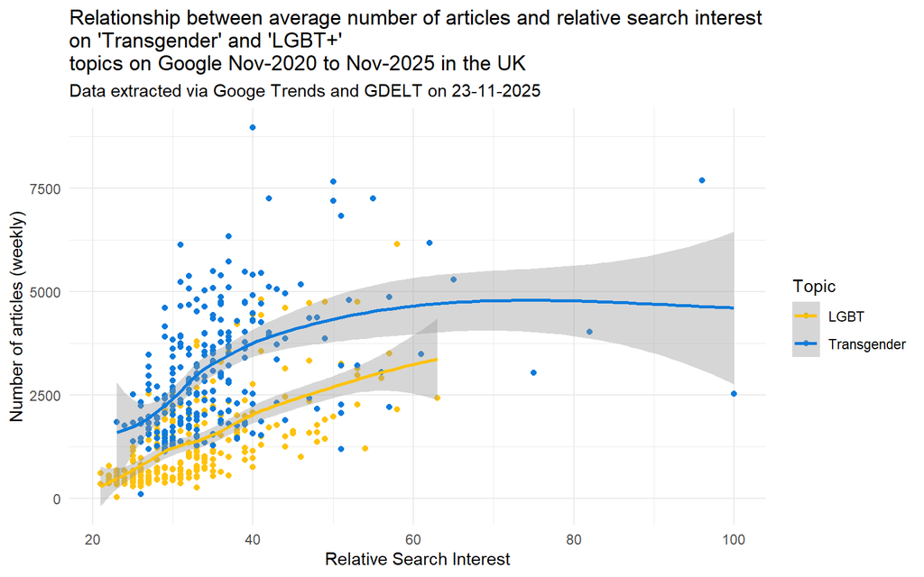

```r
scatter_vol <- full_data_clean %>%
  ggplot(aes(x = hits, y = weekly_count, colour = keyword)) +
  geom_point() +
  geom_smooth(method = "auto")+
  labs(title = "Relationship between average number of articles and relative search interest\non 'Transgender' and 'LGBT+'\ntopics on Google Nov-2020 to Nov-2025 in the UK",
       subtitle = "Data extracted via Googe Trends and GDELT on 23-11-2025",
       y = "Number of articles (weekly)",
       x = "Relative Search Interest",
       colour = "Topic") +
  scale_colour_manual(values = c("#FFC20A", "#0C7BDC")) +
  theme_minimal()
scatter_vol
```

## 4.3 Correlation between tone and search interest

The correlation between tone and RSI (hits) was computed using:

- ‘Transgender’ search term: both Spearman’s Rho and Kendall’s Tau B, following a significant Shapiro Wilks test. Spearman’s Rho was initially used but due to ties, Kendall’s Tau B was preferred.
- ‘LGBT’ search term: Pearson’s r test was used following a non-significant Shapiro Wilks test.

However, overall tone does not appear to have a particularly strong relationship to RSI.

These results are exploratory and do not control for potential confounding factors such as seasonality or media volume. Additional, unaccounted-for factors could be masking a potential association between these variables.

```r
shapiro.test(trans_full_df$week_avg_sentiment) #p<0.001
```

```
##
##  Shapiro-Wilk normality test
##
## data:  trans_full_df$week_avg_sentiment
## W = 0.97318, p-value = 8.223e-05
```

```r
shapiro.test(lgbt_full_df$week_avg_sentiment) #p=0.172
```

```
##
##  Shapiro-Wilk normality test
##
## data:  lgbt_full_df$week_avg_sentiment
## W = 0.992, p-value = 0.1715
```

```r
cor.test(trans_full_df$hits, trans_full_df$week_avg_sentiment, method = "spearman")
```

```
##
##  Spearman's rank correlation rho
##
## data:  trans_full_df$hits and trans_full_df$week_avg_sentiment
## S = 2982607, p-value = 0.7702
## alternative hypothesis: true rho is not equal to 0
## sample estimates:
##         rho
## -0.01820128
```

```r
cor.test(trans_full_df$hits, trans_full_df$week_avg_sentiment, method = "kendall")
```

```
##
##  Kendall's rank correlation tau
##
## data:  trans_full_df$hits and trans_full_df$week_avg_sentiment
## z = -0.30307, p-value = 0.7618
## alternative hypothesis: true tau is not equal to 0
## sample estimates:
##         tau
## -0.01290633
```

```r
cor.test(lgbt_full_df$hits, lgbt_full_df$week_avg_sentiment, method = "pearson")
```

```
##
##  Pearson's product-moment correlation
##
## data:  lgbt_full_df$hits and lgbt_full_df$week_avg_sentiment
## t = 1.0472, df = 258, p-value = 0.296
## alternative hypothesis: true correlation is not equal to 0
## 95 percent confidence interval:
##  -0.05704788  0.18524485
## sample estimates:
##        cor
## 0.06505729
```

```
## Ignoring unknown labels:
## • legend : "Topic"
```

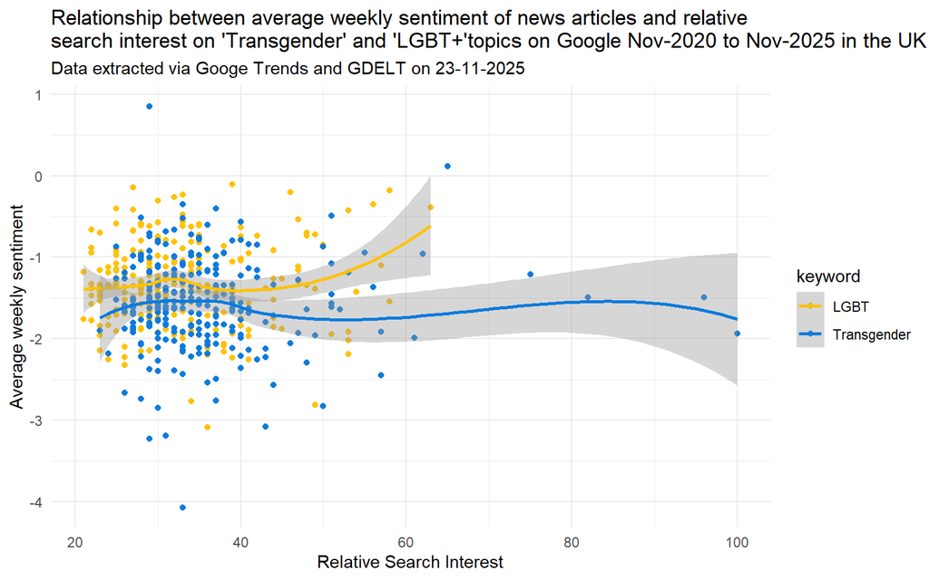

```r
scatter_tone <- full_data_clean %>%
  ggplot(aes(x = hits, y = week_avg_sentiment, colour = keyword)) +
  geom_point() +
  geom_smooth(method = "auto")+
  labs(title = "Relationship between average weekly sentiment of news articles and relative\nsearch interest on 'Transgender' and 'LGBT+'topics on Google Nov-2020 to Nov-2025 in the UK",
       subtitle = "Data extracted via Googe Trends and GDELT on 23-11-2025",
       y = "Average weekly sentiment",
       x = "Relative Search Interest",
       legend = "Topic") +
  scale_colour_manual(values = c("#FFC20A", "#0C7BDC")) +
  theme_minimal()
scatter_tone
```

## 4.4 Regression modelling volume and tone as predictive factors

For the trans search term I found that:

- There was small but significant effect of news volume on RSI, with increases in news volume being associated with small increases in RSI. However, this model had a relatively low R2, suggesting that there are other factors driving search interest, and/or that the relationship is not linear. This model also did not control for seasonal or lagged effects.
- When adding tone as an additional predictor, I found that it has no predictive value producing a small, non-significant coefficient with a high standard error. The model’s R2 also showed almost not change suggesting that tone added no additional explanatory value.
- Finally, I found that when adding month as a predictor, R2 improved slightly. The lower order polynomial contrasts (linear, quadratic, cubic) were not significant, but higher order polynomial relationships were. This suggests that there is a relatively complex seasonal structure affecting RSI when accounting for media volume.

Overall, these findings suggest that for the ‘transgender’ term, RSI has an association with media volume as well as exhibiting complex seasonal patterns.

```r
simple_trans_model <- lm(hits ~ weekly_count, data = subset(full_data_clean, keyword == "Transgender"))
summary(simple_trans_model)
```

```
##
## Call:
## lm(formula = hits ~ weekly_count, data = subset(full_data_clean,
##     keyword == "Transgender"))
##
## Residuals:
##     Min      1Q  Median      3Q     Max
## -13.245  -4.677  -1.715   1.623  65.628
##
## Coefficients:
##               Estimate Std. Error t value Pr(>|t|)
## (Intercept)  2.744e+01  1.274e+00  21.529  < 2e-16 ***
## weekly_count 2.737e-03  3.777e-04   7.246 4.96e-12 ***
## ---
## Signif. codes:  0 '***' 0.001 '**' 0.01 '*' 0.05 '.' 0.1 ' ' 1
##
## Residual standard error: 8.908 on 258 degrees of freedom
## Multiple R-squared:  0.1691, Adjusted R-squared:  0.1659
## F-statistic: 52.51 on 1 and 258 DF,  p-value: 4.957e-12
```

```r
tone_trans_model <- lm(hits ~ weekly_count + week_avg_sentiment, data = subset(full_data_clean, keyword == "Transgender"))
summary(tone_trans_model)
```

```
##
## Call:
## lm(formula = hits ~ weekly_count + week_avg_sentiment, data = subset(full_data_clean,
##     keyword == "Transgender"))
##
## Residuals:
##     Min      1Q  Median      3Q     Max
## -13.291  -4.681  -1.721   1.640  65.618
##
## Coefficients:
##                      Estimate Std. Error t value Pr(>|t|)
## (Intercept)        27.3914853  2.0333399  13.471  < 2e-16 ***
## weekly_count        0.0027375  0.0003787   7.229 5.56e-12 ***
## week_avg_sentiment -0.0277696  0.9871887  -0.028    0.978
## ---
## Signif. codes:  0 '***' 0.001 '**' 0.01 '*' 0.05 '.' 0.1 ' ' 1
##
## Residual standard error: 8.925 on 257 degrees of freedom
## Multiple R-squared:  0.1691, Adjusted R-squared:  0.1626
## F-statistic: 26.15 on 2 and 257 DF,  p-value: 4.587e-11
```

```r
trans_model_month <- lm(hits ~ weekly_count + month, data = subset(full_data_clean, keyword == "Transgender"))
summary(trans_model_month)
```

```
##
## Call:
## lm(formula = hits ~ weekly_count + month, data = subset(full_data_clean,
##     keyword == "Transgender"))
##
## Residuals:
##     Min      1Q  Median      3Q     Max
## -15.420  -4.047  -1.683   1.876  62.013
##
## Coefficients:
##                Estimate Std. Error t value Pr(>|t|)
## (Intercept)  28.5076299  1.3967761  20.410  < 2e-16 ***
## weekly_count  0.0023961  0.0004209   5.693 3.54e-08 ***
## month.L      -3.6925837  2.0396800  -1.810  0.07145 .
## month.Q      -0.8111472  1.8896781  -0.429  0.66811
## month.C       2.0472940  1.9140237   1.070  0.28583
## month^4       0.0115779  1.8886863   0.006  0.99511
## month^5       0.1551142  1.9120383   0.081  0.93541
## month^6      -1.4409166  1.9237355  -0.749  0.45456
## month^7      -1.2256726  1.8895171  -0.649  0.51715
## month^8      -0.8651301  1.8913814  -0.457  0.64778
## month^9       4.9859412  1.9061558   2.616  0.00945 **
## month^10     -4.2056552  1.9007550  -2.213  0.02784 *
## month^11     -0.7220005  1.9162999  -0.377  0.70667
## ---
## Signif. codes:  0 '***' 0.001 '**' 0.01 '*' 0.05 '.' 0.1 ' ' 1
##
## Residual standard error: 8.801 on 247 degrees of freedom
## Multiple R-squared:  0.2235, Adjusted R-squared:  0.1858
## F-statistic: 5.925 on 12 and 247 DF,  p-value: 4.703e-09
```

For ‘LGBT’:

- There was a small but significant relationship where increases in news volume showed small increases in RSI. The R2 for this model was much higher than for the equivalent model for’transgender’. This appears to suggest that LGBT search behaviour is partly driven by news cycles.
- Tone appeared to be a significant predictor in models without seasonal controls. However, adding seasonality to the previous model found that when accounting for seasonal variation, tone loses its predictive power, indicating that the apparent effects were largely driven by seasonal structure rather than sentiment. This suggests that, overall, tone does not have a substantial affect on RSI when controlling for media volume.
- Seasonality strongly influences RSI, with RSI declining on average across Jan to Dec with a roughly linear trend. This trend had more complexity as both the quadratic and several higher-order polynomials saw significant effects suggesting a complex but highly structured seasonal cycle affecting RSI when media volume and tone are held constant.

Overall this suggests that RSI is affected by a highly structured seasonal cycle, and that media volume and RSI are associated.

```r
simple_lgbt_model <- lm(hits ~ weekly_count, data = subset(full_data_clean, keyword == "LGBT"))
summary(simple_lgbt_model)
```

```
##
## Call:
## lm(formula = hits ~ weekly_count, data = subset(full_data_clean,
##     keyword == "LGBT"))
##
## Residuals:
##     Min      1Q  Median      3Q     Max
## -11.664  -4.575  -1.093   3.129  25.050
##
## Coefficients:
##               Estimate Std. Error t value Pr(>|t|)
## (Intercept)  2.605e+01  6.438e-01   40.46   <2e-16 ***
## weekly_count 4.894e-03  3.762e-04   13.01   <2e-16 ***
## ---
## Signif. codes:  0 '***' 0.001 '**' 0.01 '*' 0.05 '.' 0.1 ' ' 1
##
## Residual standard error: 6.212 on 258 degrees of freedom
## Multiple R-squared:  0.3961, Adjusted R-squared:  0.3937
## F-statistic: 169.2 on 1 and 258 DF,  p-value: < 2.2e-16
```

```r
tone_lgbt_model <- lm(hits ~ weekly_count + week_avg_sentiment, data = subset(full_data_clean, keyword == "LGBT"))
summary(tone_lgbt_model)
```

```
##
## Call:
## lm(formula = hits ~ weekly_count + week_avg_sentiment, data = subset(full_data_clean,
##     keyword == "LGBT"))
##
## Residuals:
##     Min      1Q  Median      3Q     Max
## -15.078  -4.070  -1.125   3.094  22.340
##
## Coefficients:
##                     Estimate Std. Error t value Pr(>|t|)
## (Intercept)        2.950e+01  1.124e+00  26.242  < 2e-16 ***
## weekly_count       5.129e-03  3.727e-04  13.761  < 2e-16 ***
## week_avg_sentiment 2.828e+00  7.635e-01   3.704 0.000259 ***
## ---
## Signif. codes:  0 '***' 0.001 '**' 0.01 '*' 0.05 '.' 0.1 ' ' 1
##
## Residual standard error: 6.064 on 257 degrees of freedom
## Multiple R-squared:  0.4267, Adjusted R-squared:  0.4222
## F-statistic: 95.63 on 2 and 257 DF,  p-value: < 2.2e-16
```

```r
lgbt_model_month <- lm(hits ~ weekly_count + week_avg_sentiment +month, data = subset(full_data_clean, keyword == "LGBT"))
summary(lgbt_model_month)
```

```
##
## Call:
## lm(formula = hits ~ weekly_count + week_avg_sentiment + month,
##     data = subset(full_data_clean, keyword == "LGBT"))
##
## Residuals:
##      Min       1Q   Median       3Q      Max
## -11.6609  -2.8226  -0.4902   2.3277  20.8664
##
## Coefficients:
##                     Estimate Std. Error t value Pr(>|t|)
## (Intercept)        28.832512   0.891477  32.342  < 2e-16 ***
## weekly_count        0.003782   0.000298  12.692  < 2e-16 ***
## week_avg_sentiment  0.870682   0.634261   1.373 0.171080
## month.L            -9.375511   0.988845  -9.481  < 2e-16 ***
## month.Q            -4.804756   0.971729  -4.945 1.41e-06 ***
## month.C             0.934759   0.991606   0.943 0.346773
## month^4             4.693378   0.987780   4.751 3.44e-06 ***
## month^5            -3.419239   0.978298  -3.495 0.000562 ***
## month^6            -7.377985   0.997135  -7.399 2.16e-12 ***
## month^7             5.094192   1.000452   5.092 7.05e-07 ***
## month^8             0.382442   0.975327   0.392 0.695312
## month^9            -1.989318   1.004156  -1.981 0.048695 *
## month^10           -0.527487   0.976625  -0.540 0.589608
## month^11            3.292210   0.994045   3.312 0.001066 **
## ---
## Signif. codes:  0 '***' 0.001 '**' 0.01 '*' 0.05 '.' 0.1 ' ' 1
##
## Residual standard error: 4.517 on 246 degrees of freedom
## Multiple R-squared:  0.6956, Adjusted R-squared:  0.6795
## F-statistic: 43.23 on 13 and 246 DF,  p-value: < 2.2e-16
```

## 4.5 Lag: media volume and RSI

Several tests were run to determine the effect of media lag i.e. does a spike in media volume precede a rise in RSI or vice versa. Often in news cycles, an increase in reporting on a story will bring about an increase in interest shortly after.

Tests run included:

- Cross-correlation function to measure the similarity of volume and RSI at different lags.
- Distributed Lag Modelling to account for lags when modelling the behaviour of volume and RSI.

### 4.5.1 Cross-correlation

Cross-correlation function (CCF) measures the similarity between two time series at different lags and is commonly used to investigate whether changes in one series precede changes in another over time. Cross-correlation can be computed regardless of the data distribution because it is defined in terms of covariance and expectations rather than distributional assumptions.

Autocorrelation and trends can affect the interpretation offered by CCF so it is used as a useful exploratory tool to understand the temporal alignment of volume and RSI rather than to make solid conclusions on the relationship between them.

A maximum lag of 12 weeks was chosen as this represents a quarter of the year, allowing me to capture short-term media attention while avoiding over-interpreting longer-term correlations.

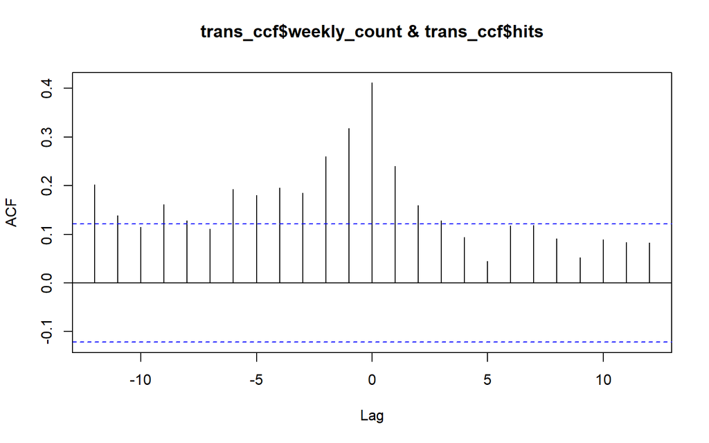

```r
trans_ccf <- full_data_clean %>%
  filter(keyword == "Transgender")
ccf(trans_ccf$weekly_count, trans_ccf$hits, lag.max = 12, plot = TRUE)
```

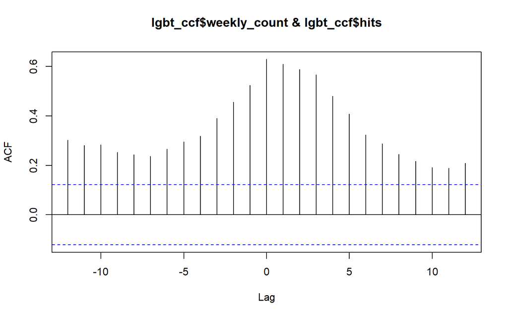

```r
lgbt_ccf <- full_data_clean %>%
  filter(keyword == "LGBT")
ccf(lgbt_ccf$weekly_count, lgbt_ccf$hits, lag.max = 12, plot = TRUE)
```

### 4.5.2 Distributed Lag Modelling

Distributed Lag Model (DLM) is a type of regression used to understand how one variable effects another when the effect does not happen immediately but unfolds over several time periods (lags). It allows the assessment of both immediate and delayed associations.

Following results observed in CCF, I ran DLM to further understand the impact of lags on the relationship between media volume and RSI. I explored two different models, one to understand the relationship between RSI and media volume (both immediate and lagged), the other to understand the relationship between media volume, lagged media volume influencing current coverage, and RSI. I used the Newey-West estimator to account for autocorrelation in the second model.

DLM for ‘transgender’ found that:

- Lags in news coverage did not predict future RSI when accounting for media volume, suggesting that public search behaviour responds mostly to immediate events rather than delayed media effects.
- However, modeling media volume predicted by a combination of search interest and media momentum over time found that when RSI is high, we also see more news coverage suggesting that Google search interest and news media often move together.
- Furthermore, independent of Google search interest, media volume had a very short-term effect (lag 1), suggesting it has its own momentum over very short span of time with coverage in one week predicting coverage the following week. This is to be expected as often news media will report on similar issues, with stories being successively picked up by different outlets, and journalists will often follow up on previous stories.
- Interestingly, there was also evidence of medium-term effects at lag 4, suggesting that media volume from a month ago is still associated with coverage four weeks later when accounting for RSI and the previous week’s coverage. This could be reflecting monthly political cycles, legal timelines, follow-up reporting, and editorial scheduling.

Similarly for the LGBT search term:

- DLM showed that search interest appears to respond immediately to media volume but shows no evidence of delayed effects when accounting for media coverage in the same week.
- For the LGBT+ topic, higher RSI was also associated with increased news coverage in the same week, suggesting that search interest and media volume often move together.
- Independent of search interest, media volume showed short-term effects (lag 1-2), with coverage in one week predicting coverage in the following week, reflecting expected journalistic and editorial momentum. In contrast to the trans keyword, no medium-term lagged effects were observed for LGBT+ coverage after correcting for autocorrelation, suggesting that media attention to LGBT+ topics is more short-lived and less structured over time.

This analysis overall showed that for both, there is a immediate-term association between media volume and search interest, with both search terms showing short-term momentum for media volume. In addition, trans search terms are more likely to also have medium-term momentum, suggesting that media attention has more complex patterns for this topic.

```r
trans_dlm <- lm(hits ~ weekly_count + lag(weekly_count, 1) + lag(weekly_count, 2) + lag(weekly_count, 3) + lag(weekly_count, 4) + lag(weekly_count, 5) + lag(weekly_count, 6), data = subset(full_data_clean, keyword == "Transgender"))
summary(trans_dlm)
```

```
##
## Call:
## lm(formula = hits ~ weekly_count + lag(weekly_count, 1) + lag(weekly_count,
##     2) + lag(weekly_count, 3) + lag(weekly_count, 4) + lag(weekly_count,
##     5) + lag(weekly_count, 6), data = subset(full_data_clean,
##     keyword == "Transgender"))
##
## Residuals:
##     Min      1Q  Median      3Q     Max
## -11.692  -4.664  -1.662   1.683  65.209
##
## Coefficients:
##                        Estimate Std. Error t value Pr(>|t|)
## (Intercept)          27.5917183  1.5647657  17.633  < 2e-16 ***
## weekly_count          0.0023836  0.0006017   3.961 9.77e-05 ***
## lag(weekly_count, 1)  0.0003092  0.0007156   0.432    0.666
## lag(weekly_count, 2)  0.0006379  0.0007153   0.892    0.373
## lag(weekly_count, 3) -0.0007811  0.0007100  -1.100    0.272
## lag(weekly_count, 4)  0.0001271  0.0007144   0.178    0.859
## lag(weekly_count, 5) -0.0003150  0.0006996  -0.450    0.653
## lag(weekly_count, 6)  0.0003085  0.0005920   0.521    0.603
## ---
## Signif. codes:  0 '***' 0.001 '**' 0.01 '*' 0.05 '.' 0.1 ' ' 1
##
## Residual standard error: 8.945 on 246 degrees of freedom
##   (6 observations deleted due to missingness)
## Multiple R-squared:  0.1673, Adjusted R-squared:  0.1436
## F-statistic: 7.063 on 7 and 246 DF,  p-value: 1.093e-07
```

```r
trans_dlm2 <- lm(weekly_count ~ hits + lag(weekly_count, 1) + lag(weekly_count, 2) + lag(weekly_count, 3) + lag(weekly_count, 4) + lag(weekly_count, 5) + lag(weekly_count, 6), data = subset(full_data_clean, keyword == "Transgender"))
summary(trans_dlm2)
```

```
##
## Call:
## lm(formula = weekly_count ~ hits + lag(weekly_count, 1) + lag(weekly_count,
##     2) + lag(weekly_count, 3) + lag(weekly_count, 4) + lag(weekly_count,
##     5) + lag(weekly_count, 6), data = subset(full_data_clean,
##     keyword == "Transgender"))
##
## Residuals:
##     Min      1Q  Median      3Q     Max
## -2221.2  -463.9   -97.4   337.8  4726.2
##
## Coefficients:
##                        Estimate Std. Error t value Pr(>|t|)
## (Intercept)          -311.27766  241.05783  -1.291   0.1978
## hits                   25.15682    6.35055   3.961 9.77e-05 ***
## lag(weekly_count, 1)    0.60138    0.06275   9.583  < 2e-16 ***
## lag(weekly_count, 2)   -0.06781    0.07347  -0.923   0.3570
## lag(weekly_count, 3)    0.09330    0.07287   1.280   0.2016
## lag(weekly_count, 4)    0.16354    0.07266   2.251   0.0253 *
## lag(weekly_count, 5)   -0.06359    0.07179  -0.886   0.3766
## lag(weekly_count, 6)    0.07800    0.06064   1.286   0.1996
## ---
## Signif. codes:  0 '***' 0.001 '**' 0.01 '*' 0.05 '.' 0.1 ' ' 1
##
## Residual standard error: 918.9 on 246 degrees of freedom
##   (6 observations deleted due to missingness)
## Multiple R-squared:  0.6202, Adjusted R-squared:  0.6094
## F-statistic: 57.39 on 7 and 246 DF,  p-value: < 2.2e-16
```

```r
coeftest(trans_dlm2, vcov. = NeweyWest(trans_dlm2, lag = 6))
```

```
##
## t test of coefficients:
##
##                         Estimate  Std. Error t value  Pr(>|t|)
## (Intercept)          -311.277660  219.349100 -1.4191 0.1571365
## hits                   25.156822    6.652535  3.7815 0.0001957 ***
## lag(weekly_count, 1)    0.601379    0.059737 10.0670 < 2.2e-16 ***
## lag(weekly_count, 2)   -0.067805    0.077257 -0.8777 0.3809839
## lag(weekly_count, 3)    0.093297    0.070626  1.3210 0.1877261
## lag(weekly_count, 4)    0.163544    0.063432  2.5783 0.0105122 *
## lag(weekly_count, 5)   -0.063590    0.073877 -0.8608 0.3902096
## lag(weekly_count, 6)    0.078003    0.067262  1.1597 0.2472943
## ---
## Signif. codes:  0 '***' 0.001 '**' 0.01 '*' 0.05 '.' 0.1 ' ' 1
```

```r
lgbt_dlm <- lm(hits ~ weekly_count + lag(weekly_count, 1) + lag(weekly_count, 2) + lag(weekly_count, 3) + lag(weekly_count, 4) + lag(weekly_count, 5) + lag(weekly_count, 6), data = subset(full_data_clean, keyword == "LGBT"))
summary(lgbt_dlm)
```

```
##
## Call:
## lm(formula = hits ~ weekly_count + lag(weekly_count, 1) + lag(weekly_count,
##     2) + lag(weekly_count, 3) + lag(weekly_count, 4) + lag(weekly_count,
##     5) + lag(weekly_count, 6), data = subset(full_data_clean,
##     keyword == "LGBT"))
##
## Residuals:
##     Min      1Q  Median      3Q     Max
## -12.126  -4.293  -1.391   2.934  24.512
##
## Coefficients:
##                        Estimate Std. Error t value Pr(>|t|)
## (Intercept)           2.668e+01  7.222e-01  36.936  < 2e-16 ***
## weekly_count          5.511e-03  7.702e-04   7.155 9.58e-12 ***
## lag(weekly_count, 1)  6.355e-05  9.581e-04   0.066    0.947
## lag(weekly_count, 2)  1.181e-04  9.601e-04   0.123    0.902
## lag(weekly_count, 3) -3.704e-06  9.584e-04  -0.004    0.997
## lag(weekly_count, 4) -1.314e-03  9.582e-04  -1.372    0.171
## lag(weekly_count, 5)  2.168e-04  9.512e-04   0.228    0.820
## lag(weekly_count, 6) -3.888e-05  7.667e-04  -0.051    0.960
## ---
## Signif. codes:  0 '***' 0.001 '**' 0.01 '*' 0.05 '.' 0.1 ' ' 1
##
## Residual standard error: 6.226 on 246 degrees of freedom
##   (6 observations deleted due to missingness)
## Multiple R-squared:  0.4148, Adjusted R-squared:  0.3982
## F-statistic: 24.91 on 7 and 246 DF,  p-value: < 2.2e-16
```

```r
lgbt_dlm2 <- lm(weekly_count ~ hits + lag(weekly_count, 1) + lag(weekly_count, 2) + lag(weekly_count, 3) + lag(weekly_count, 4) + lag(weekly_count, 5) + lag(weekly_count, 6), data = subset(full_data_clean, keyword == "LGBT"))
summary(lgbt_dlm2)
```

```
##
## Call:
## lm(formula = weekly_count ~ hits + lag(weekly_count, 1) + lag(weekly_count,
##     2) + lag(weekly_count, 3) + lag(weekly_count, 4) + lag(weekly_count,
##     5) + lag(weekly_count, 6), data = subset(full_data_clean,
##     keyword == "LGBT"))
##
## Residuals:
##      Min       1Q   Median       3Q      Max
## -1329.54  -244.27   -16.85   153.54  2630.03
##
## Coefficients:
##                        Estimate Std. Error t value Pr(>|t|)
## (Intercept)          -714.55575  131.49115  -5.434 1.32e-07 ***
## hits                   31.25781    4.36873   7.155 9.58e-12 ***
## lag(weekly_count, 1)    0.60927    0.06081  10.019  < 2e-16 ***
## lag(weekly_count, 2)    0.11190    0.07196   1.555    0.121
## lag(weekly_count, 3)    0.02623    0.07216   0.364    0.716
## lag(weekly_count, 4)    0.04176    0.07239   0.577    0.565
## lag(weekly_count, 5)   -0.04956    0.07158  -0.692    0.489
## lag(weekly_count, 6)    0.02854    0.05771   0.494    0.621
## ---
## Signif. codes:  0 '***' 0.001 '**' 0.01 '*' 0.05 '.' 0.1 ' ' 1
##
## Residual standard error: 468.9 on 246 degrees of freedom
##   (6 observations deleted due to missingness)
## Multiple R-squared:  0.8007, Adjusted R-squared:  0.7951
## F-statistic: 141.2 on 7 and 246 DF,  p-value: < 2.2e-16
```

```r
coeftest(lgbt_dlm2, vcov. = NeweyWest(lgbt_dlm2, lag = 6))
```

```
##
## t test of coefficients:
##
##                         Estimate  Std. Error t value  Pr(>|t|)
## (Intercept)          -714.555754  204.115528 -3.5007 0.0005507 ***
## hits                   31.257813    7.794186  4.0104 8.044e-05 ***
## lag(weekly_count, 1)    0.609274    0.077856  7.8256 1.495e-13 ***
## lag(weekly_count, 2)    0.111898    0.052241  2.1420 0.0331787 *
## lag(weekly_count, 3)    0.026235    0.087855  0.2986 0.7654862
## lag(weekly_count, 4)    0.041758    0.114838  0.3636 0.7164492
## lag(weekly_count, 5)   -0.049561    0.082042 -0.6041 0.5463367
## lag(weekly_count, 6)    0.028537    0.046128  0.6187 0.5367160
## ---
## Signif. codes:  0 '***' 0.001 '**' 0.01 '*' 0.05 '.' 0.1 ' ' 1
```

# 5 CONCLUSIONS

Analysis of Google Trends relative search interest (RSI) and GDELT news volume and tone data for keywords ‘LGBT’ and ‘transgender’ showed persistent seasonal patterns and a strong association between news coverage and search interest. These findings suggests that LGBT+ and trans-related search behaviour in the UK is often event-driven and influenced by recurring temporal structures, including monthly political, legislative, and journalistic cycles.

Although this analysis cannot establish causal effects, the results indicate a close connection between news media coverage and public search behaviour, highlighting the importance of media attention in shaping patterns of information seeking. Given that Google searches are frequently one of the first sources people turn to for information and education, understanding these dynamics is particularly important.

While further research is needed to better understand the mechanisms linking media coverage and public search interest, this analysis suggests that news media plays a meaningful role in driving search interest, with potential knock-on implications for public understanding, awareness, and social change.